# Ford GoBike Data Visualiztaion

## by Bassant Hany

## Investigation Overview

> Discover intersting patterns

## Dataset Overview

> > This data set includes information about individual rides made in a bike-sharing system covering the greater San Francisco Bay area for the month February, 2019

## the percentage of user types

> the majority of users are subscribers making 90.5% of the total users

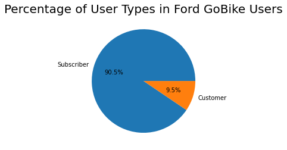

## the distribution of rides start_hour over the 24hrs of the days

> The most popular hours were 8:00 AM and 5:00 PM, which are one hour before work starts and the hour work ends, we can conclude that people tend to rent bikes right before going to work or right after finishing work

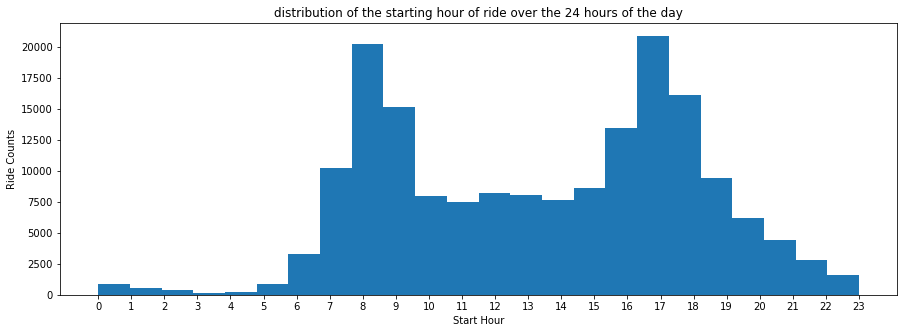

## the weekly usage of both subscribers and customers

[figure not shown]

## The correlation between User age and trip duration

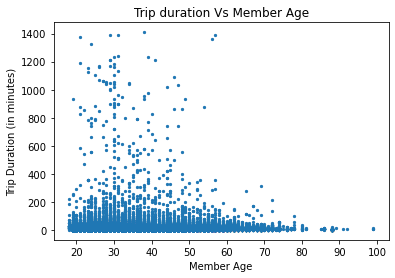

## the most common hours to end your trip for both customers and subscribers

> from here we can deduce that customers tend to use bikes during the weekend mean while subscribes don't. Also the end_hour most common values being the same as start_hour tells that most of the trips don't last for more than an hour

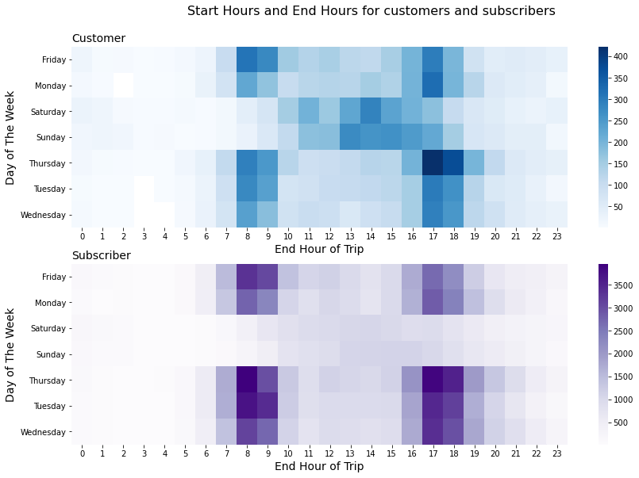

[output not shown]